# Lab 8: Variance of Sample Means and Correlation

In this lab we will learn about [the variance of sample means](https://inferentialthinking.com/chapters/14/5/Variability_of_the_Sample_Mean.html) as well as ways to understand and quantify [the association between two variables](https://inferentialthinking.com/chapters/15/1/Correlation.html).

```python
name = "Hannah Joseph"
name
```

```
'Hannah Joseph'
```

```python
## import statements
# These lines load the tests.
from gofer.ok import check
import numpy as np
from datascience import *
import pandas as pd
import matplotlib
%matplotlib inline
import matplotlib.pyplot as plt
plt.style.use('ggplot')
# Fix for datascience plots
import collections as collections
import collections.abc as abc
collections.Iterable = abc.Iterable
```

## 1. How Faithful is Old Faithful?

(Note: clever title comes from [here](http://web.pdx.edu/~jfreder/M212/oldfaithful.pdf).)

Old Faithful is a geyser in Yellowstone National Park in the central United States. It's famous for erupting on a fairly regular schedule. You can see a video below.

```python
# For the curious: this is how to display a YouTube video in a
# Jupyter notebook.  The argument to YouTubeVideo is the part
# of the URL (called a "query parameter") that identifies the
# video.  For example, the full URL for this video is:
#   https://www.youtube.com/watch?v=wE8NDuzt8eg
from IPython.display import YouTubeVideo
YouTubeVideo("wE8NDuzt8eg")
```

[video not shown]

Some of Old Faithful's eruptions last longer than others. When it has a long eruption, there's generally a longer wait until the next eruption.

If you visit Yellowstone, you might want to predict when the next eruption will happen, so you can see the rest of the park and come to see the geyser when it erupts. To predict one variable from another, the first step is to understand the association between them.

The dataset has one row for each observed eruption. It includes the following columns:

- **duration**: Eruption duration, in minutes
- **wait**: Time between this eruption and the next, also in minutes

Run the next cell to load the dataset.

```python
faithful = Table.read_table("faithful-new.csv")
faithful
```

| duration | wait |
| --- | --- |
| 3.6 | 79 |
| 1.8 | 54 |
| 3.333 | 74 |
| 2.283 | 62 |
| 4.533 | 85 |
| 2.883 | 55 |
| 4.7 | 88 |
| 3.6 | 85 |
| 1.95 | 51 |
| 4.35 | 85 |

... (262 rows omitted)

**Question 1**

Make a scatter plot of the data. It's conventional to put the column we will try to predict on the vertical axis and the other column on the horizontal axis. The predictor column is the independent or often labeled x variable.

```python
predictor_col = 'duration'
predictor_col

# This is the label as a string of the predictor column or independent x variable
```

```
'duration'
```

#### To plot a scatter plot need arrays froom columns of data

See example below to examine the Philadelphia Phillies winning percentage, `PCT`, as a function of year, `YEAR`.

```python
# EXAMPLE DATA AND SCATTER PLOT
exampledata = Table().with_columns( \
     'YEAR', np.arange(2013,2023,1), \
     'PCT', make_array(.451,.451,.389,.438,.407,.494,.500,.467,.506,.537))
exampledata
```

| YEAR | PCT |
| --- | --- |
| 2013 | 0.451 |
| 2014 | 0.451 |
| 2015 | 0.389 |
| 2016 | 0.438 |
| 2017 | 0.407 |
| 2018 | 0.494 |
| 2019 | 0.5 |
| 2020 | 0.467 |
| 2021 | 0.506 |
| 2022 | 0.537 |

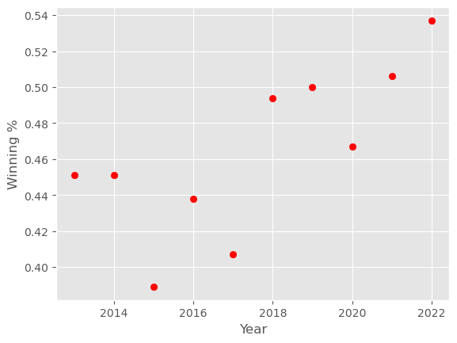

```python
plt.scatter(exampledata.column('YEAR'),exampledata.column('PCT'),color="red") # need to use each column as an array to plot
plt.xlabel("Year")
plt.ylabel("Winning %")
#plt.show()
```

#### Regression Line

We can fit the observed trend using linear regression. We seek to understand the fundamental priciples behind this important manner of fitting data.

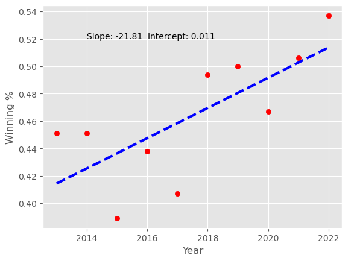

```python
plt.scatter(exampledata.column('YEAR'),exampledata.column('PCT'),color="red") # need to use each column as an array to plot
plt.xlabel("Year")
plt.ylabel("Winning %")
# calculate equation for regression line
z = np.polyfit(exampledata.column('YEAR'),exampledata.column('PCT'), 1)
p = np.poly1d(z)
plt.annotate("Slope: "+str(round(p[0],2))+"  Intercept: "+str(round(p[1],4)),xy=(2014,0.52)) # Annotate with slope and intercept
# add regression line to plot
plt.plot(exampledata.column('YEAR'), p(exampledata.column('YEAR')),color="blue", linewidth=3, linestyle="--")
plt.show()
```

#### Now try to plot the `faithful` data

```python
faithful.stats() # Helpful check on data, not neccessary in this case
```

| statistic | duration | wait |
| --- | --- | --- |
| min | 1.6 | 43 |
| max | 5.1 | 96 |
| median | 4 | 76 |
| sum | 948.677 | 19284 |

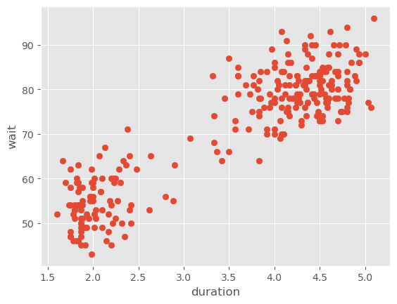

```python
# Now plot
plt.scatter(faithful.column(predictor_col),faithful.column('wait'))
plt.xlabel("duration")
plt.ylabel("wait")
plt.savefig("scatter.png") # Helpful way to save figure
plt.show()
```

##### Now try yourself, plot the reverse `wait` versus `duration`

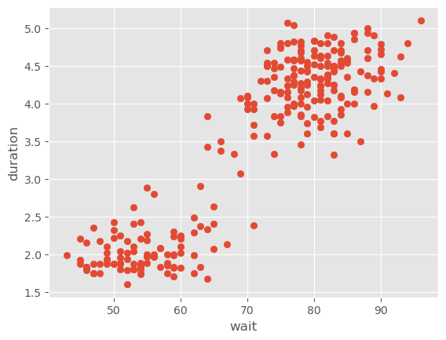

```python
plt.scatter(faithful.column('wait'), faithful.column(predictor_col))
plt.xlabel("wait")
plt.ylabel("duration")
plt.savefig("scatter_reverse.png")
plt.show()
```

```python
check('tests/q1.py')
```

All tests passed!

**Question 2**

Look at the scatter plot. Are eruption duration and waiting time roughly linearly related? Is the relationship positive, as we claimed earlier? You may want to consult [the textbook chapter 15](https://inferentialthinking.com/chapters/15/1/Correlation.html#the-correlation-coefficient) for the definition of "linearly related."

*The eruption duration and waiting time are roughly lineraly related as the relationship is positive.*

Standard units makes the analysis of the relationship between duration and wait more straightforward. First, we'll plot the data in standard units. Recall that, if `nums` is an array of numbers, then

```
(nums - np.mean(nums)) / np.std(nums)
```

is an array of those numbers in standard units.

**Question 3**

Compute the mean and standard deviation of the eruption durations and waiting times. **Then** create a table called `faithful_standard` containing the eruption durations and waiting times in standard units. (The columns should be named `"duration (standard units)"` and `"wait (standard units)"`.

```python
duration_mean = np.mean(faithful.column('duration'))
duration_std = np.std(faithful.column('duration'))
wait_mean = np.mean(faithful.column('wait'))
wait_std = np.std(faithful.column('wait'))

faithful_standard = Table().with_columns(
    "duration (standard units)", (faithful.column('duration') - duration_mean) / duration_std,
    "wait (standard units)", (faithful.column('wait') - wait_mean) / wait_std)
faithful_standard
```

| duration (standard units) | wait (standard units) |
| --- | --- |
| 0.0984989 | 0.597123 |
| -1.48146 | -1.24518 |
| -0.135861 | 0.228663 |
| -1.0575 | -0.655644 |
| 0.917443 | 1.03928 |
| -0.530851 | -1.17149 |
| 1.06403 | 1.26035 |
| 0.0984989 | 1.03928 |
| -1.3498 | -1.46626 |
| 0.756814 | 1.03928 |

... (262 rows omitted)

```python
check('tests/q3.py')
```

All tests passed!

**Question 4**

Plot the data again, but this time in standard units.

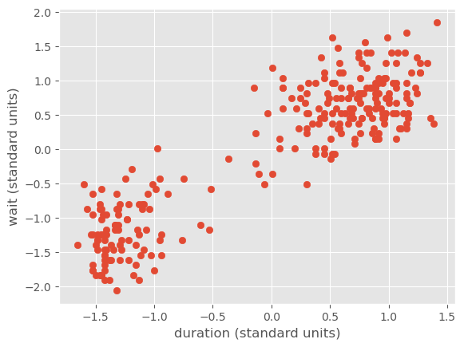

```python
# Review from above how plot a scatter plot
plt.scatter(faithful_standard.column('duration (standard units)'), faithful_standard.column('wait (standard units)'))
plt.xlabel("duration (standard units)")
plt.ylabel("wait (standard units)")
plt.show()
```

**Question 5**

Among the following numbers, which would you guess is closest to the correlation between eruption duration and waiting time in this dataset?

- -1
- 0
- 1

Assign your answer to `closest_correlation`.

```python
closest_correlation = 1
```

```python
check('tests/q5.py')
```

All tests passed!

**Question 6**

Compute the correlation `r`. *Hint:* Use `faithful_standard`. Section [15.1.2](https://inferentialthinking.com/chapters/15/1/Correlation.html#calculating-r) explains how to do this.

```python
r = np.mean(faithful_standard.column('duration (standard units)') * faithful_standard.column('wait (standard units)'))
r
```

```
0.90081116832181318
```

```python
check('tests/q6.py')
```

All tests passed!